# Bayes Rule Exercises

1. A test for cystic fibrosis has an accuracy of 99%. Specifically, we mean that: Prob(+|D) = 0.99; Prob(-|no D)= 0.99 The cystic fibrosis rate in the general population is 1 in 3,900, Prob(D) = 0.00025 If we select a random person and they test positive, what is probability that they have cystic fibrosis Prob(D|+) ? Hint: use Bayes Rule. Pr(A|B) = Pr(B|A) * Pr(A) / Pr(B)

```r
(p1 = 0.99 * 0.00025 / (0.99 * 0.00025 + 0.01 * 0.99975) )
```

```
## [1] 0.02415813
```

2. First download some baseball statistics.

```r
tmpfile <- tempfile()
tmpdir <- tempdir()
download.file("http://seanlahman.com/files/database/lahman-csv_2014-02-14.zip",tmpfile)
##this shows us files
filenames <- unzip(tmpfile,list=TRUE)
players <- read.csv(unzip(tmpfile,files="Batting.csv",exdir=tmpdir),as.is=TRUE)
unlink(tmpdir)
file.remove(tmpfile)
```

```
## [1] TRUE
```

In our first course we learned to use the dplyr package. Please review for example with [this tutorial](https://cran.r-project.org/web/packages/dplyr/vignettes/dplyr.html).

Here we use dplyr to obtain the necessary information to perform a hierarchical model.

Which of the following dplyr commands gives us the batting averages (AVG) for players with more than 500 at bats (AB) in 2012:

```
players$AVG
filter(players,yearID==2012) %>% mutate(AVG=H/AB) %>% filter(AB>=500) %>% select(AVG) coerrect
filter(players,yearID==2012) %>% mutate(AVG=H/AB) %>% select(AVG)
filter(players,yearID==2012) %>% mutate(AVG=H/AB) %>% filter(AB>=500) %>% select(AVG) %>% mutate(AVG=mean(AVG))
```

3. Edit the command above to obtain all the batting averages from 2010, 2011, 2012 and removing rows with AB < 500. What is the average of these batting averages?

```r
library(dplyr)
dat <- filter(players,yearID>=2010, yearID <=2012) %>% mutate(AVG=H/AB) %>% filter(AB>=500) %>% select(AVG)
mean(dat$AVG)
```

```
## [1] 0.2754028
```

4. What is the standard deviation of these batting averages?

```r
sd(dat$AVG)
```

```
## [1] 0.02739408
```

5. Use exploratory data analysis to decide which of the following distributions approximates the distribution of the average across players (hint: this is contained in the AVG component)?

   Poisson Normal correct F-distribution Uniform

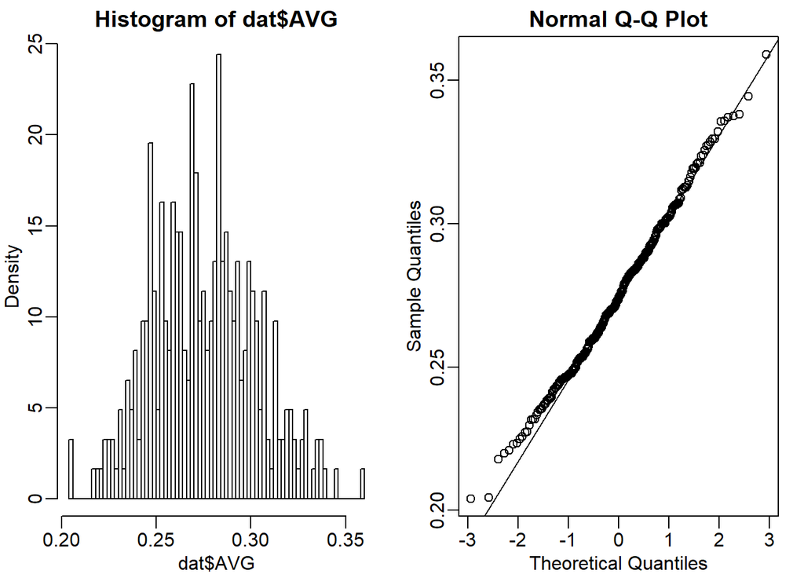

```r
library(rafalib)
mypar(1,2)
hist(dat$AVG,nc=100,freq=FALSE)
qqnorm(dat$AVG)
qqline(dat$AVG)
```

6. It is April and after 20 at bats, Jose Iglesias is batting .450 (which is very good). We can think of this as a binomial distribution with 20 trials, with probability of success p. Our sample estimate of p is .450. What is our estimate of standard deviation? Hint: This is the sum that is binomial divided by 20.

```r
# The sum (numerator of AVG) is binomial so it has SD = sqrt(Np(1-p)). The SD of a random variable times a constant is the SD of the random variable times that constant.
# For the AVG we divide by N to get sqrt(p(1-p)/N).
sqrt(0.450 * (1 - 0.450) / 20)
```

```
## [1] 0.111243
```

7. The Binomial is approximated by normal, so our sampling distribution is approximately normal with mean theta = 0.45 and SD sigma = 0.11. Earlier we used a baseball database to determine that our prior distribution for theta is Normal with mean mu = 0.275 and SD tau = 0.027. We also saw that this is the posterior mean prediction of the batting average. What is your Bayes prediction for the batting average going forward?
   $$E(\theta|y) = B\mu + (1 - B)Y \\
   = \mu + (1 - B)(Y - \mu) \\
   B = \sigma^2 / (\sigma^2 + \tau^2)$$

```r
Y = 0.450
sigma = 0.11
mu = 0.275
tau = 0.027

B = sigma^2 / (sigma^2 + tau^2)


( E_of_theta_given_Y <- B * mu + (1 - B) * Y )
```

```
## [1] 0.2849443
```

```r
#The Red Sox traded Jose Iglesias mid-season. He batted .292 the remaining of the season not .450 and much closer to the .285 estimate.
```